# Volleyball and Regression

## Volleyball

- We examine data from the 2019 NCAA Division I Women’s Volleyball season.
- There are 332 such teams from 32 conferences.
- Wisconsin is one of 14 teams in the Big 10 conference:
  - (In the distant past, the Big 10 had only 10 members.)
- Wisconsin had a very good team that won the Big 10 championship and was seeded #4 overall in the NCAA tournament.
- The NCAA tournament is a single elimination tournament with 64 teams that took place over three weekends.
  - During the first weekend, 16 teams are hosts and winners of the mini four-team tournaments advance to the second weekend as one of 16 victors.
  - During the second weekend, 4 teams are hosts and the winners of a second set of mini four-team tournaments advance to the national semifinals.
  - During the third weekend, there are two semi-final matches and the winners play the next day for the championship.
- We have two different related data sets to examine.
  - One has cumulative statistics for the teams across the entire season.
  - The second has the outcomes from each single volleyball match.

## Matches

- First to win three sets wins the match.
- Must win a set by two points.
- First four sets are played to 25 points.
  - Fourth set only played if a team has not won all three first sets.
  - Final winning score could be more than 25 if set is tied 24-24 at some point.
- Fifth and final set, if needed, played to 15 points, win by two.

## Explore the First Set of Data

```r
vb = read_csv("../../data/volleyball-team-2019.csv")
```

#### See Wisconsin

```r
vb %>%
  filter(Team == "Wisconsin") %>%
  as.data.frame()
```

```
##        Team Conference  W L   Win_pct Sets Aces Assists Block Solos
## 1 Wisconsin    Big Ten 22 6 0.7857143   97  160    1334          24
##   Block Assists Digs Kills Errors Total Attacks   Hit_pct Opp Kills Opp Errors
## 1           434 1447  1405    418          3349 0.2947148      1199        522
##   Opp Attacks   Opp_pct
## 1        3382 0.2001774
```

#### Compare Conferences by Winning Percentage

```r
conference = vb %>%
  group_by(Conference) %>%
  summarize(W = sum(W),
            L = sum(L),
            win_pct = 100 * W / (W+L)) %>%
  arrange(desc(win_pct))

conference %>%
  print(n = Inf)
```

```
## # A tibble: 32 x 4
##    Conference        W     L win_pct
##    <chr>         <dbl> <dbl>   <dbl>
##  1 Pac-12          210   151    58.2
##  2 SEC             216   160    57.4
##  3 Big Ten         240   181    57.0
##  4 Big 12          138   106    56.6
##  5 Horizon         148   119    55.4
##  6 AAC             195   159    55.1
##  7 C-USA           204   168    54.8
##  8 ACC             234   197    54.3
##  9 Ivy League      100    86    53.8
## 10 WCC             155   138    52.9
## 11 Patriot         144   129    52.7
## 12 CAA             137   124    52.5
```

[output cut: 20 more lines]

#### Examine Variables

```r
vb = vb %>%
  mutate(aces_per_set = Aces/Sets,
         assists_per_set = Assists/Sets,
         blocks_per_set = (`Block Solos` + `Block Assists`)/Sets,
         digs_per_set = Digs/Sets,
         kills_per_set = Kills/Sets,
         errors_per_set = Errors/Sets,
         attacks_per_set = `Total Attacks`/Sets,
         opp_kills_per_set = `Opp Kills`/Sets,
         opp_errors_per_set = `Opp Errors`/Sets,
         opp_attacks_per_set = `Opp Attacks`/Sets)

vb %>%
  summarize(mean_aps = mean(aces_per_set),
            mean_wp = mean(Win_pct))
```

```
## # A tibble: 1 x 2
##   mean_aps mean_wp
##      <dbl>   <dbl>
## 1     1.33   0.501
```

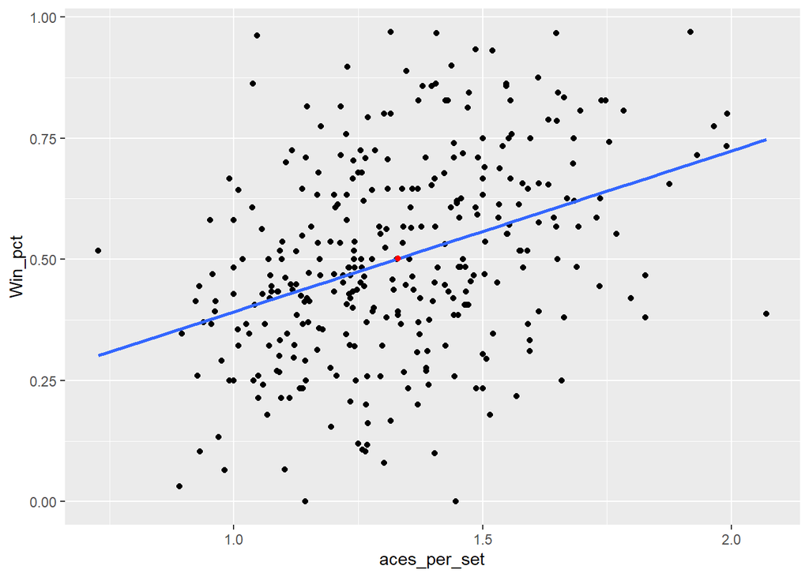

```r
ggplot(vb, aes(x=aces_per_set, y = Win_pct)) +
  geom_point() +
  geom_smooth(method = "lm", se=FALSE) +
geom_point(aes(x=1.33, y = 0.501), color="red")
```

```r
vb %>%
  summarize(r_aces = cor(aces_per_set,Win_pct))
```

```
## # A tibble: 1 x 1
##   r_aces
##    <dbl>
## 1  0.374
```

#### Which Variables Best Predict Winning Percentage

```
## # A tibble: 1 x 7
##      mx    sx    my    sy     r    b1     b0
##   <dbl> <dbl> <dbl> <dbl> <dbl> <dbl>  <dbl>
## 1  1.33 0.230 0.501 0.205 0.374 0.332 0.0600
```

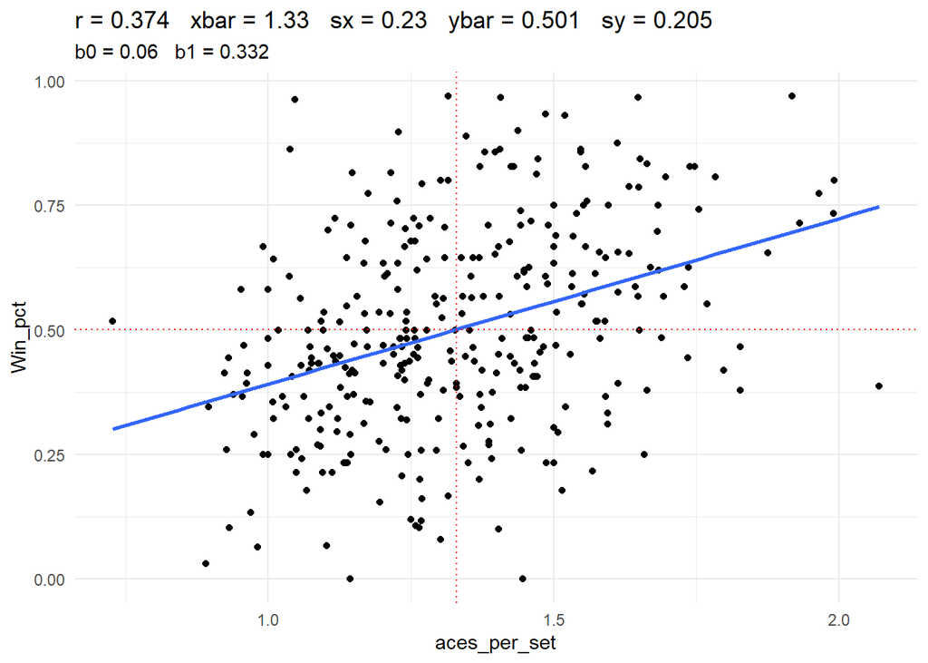

```r
## Notes:
##  .data is a data frame
##  .x and .y are variable names without parentheses
##  inside the function, put double braces around .x and .y

f = function(.data, .x, .y)
{
  out = .data %>%
    select({{.x}}, {{.y}}) %>%
    summarize(
      mx = mean( {{.x}} ),
      sx = sd( {{.x}} ),
      my = mean( {{.y}} ),
      sy = sd( {{.y}} ),
      r = cor( {{.x}}, {{.y}} ),
      b1 = r*sy/sx,
      b0 = my - b1*mx
    )
  print( out )
  title = with(out, paste("r =", round(r,3)," ",
                          "xbar =", round(mx,3)," ",
                          "sx =", round(sx,3), " ",
                          "ybar =", round(my,3)," ",
                          "sy =", round(sy,3)))
  subtitle = with(out, paste("b0 =", round(b0,3)," ",
                             "b1 =", round(b1,3)))

  p = ggplot(.data, aes(x = {{.x}}, y = {{.y}})) +
    geom_point() +
    geom_smooth(method = "lm", se = FALSE) +
    geom_vline(xintercept = out$mx, color = "red",
               linetype = "dotted") +
    geom_hline(yintercept = out$my, color = "red",
               linetype = "dotted") +
    ggtitle(title, subtitle = subtitle) +
    theme_minimal()

  plot(p)

  return ( invisible(list(stats=out, plot=p)) )
}

f(vb, aces_per_set, Win_pct)
```

```r
f(vb, assists_per_set, Win_pct)
```

```
## # A tibble: 1 x 7
##      mx    sx    my    sy     r    b1    b0
##   <dbl> <dbl> <dbl> <dbl> <dbl> <dbl> <dbl>
## 1  11.5  1.12 0.501 0.205 0.793 0.145 -1.18
```

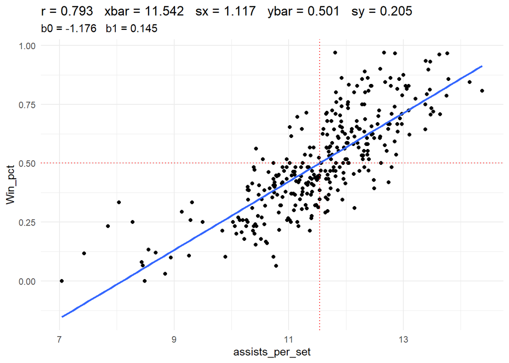

```r
f(vb, blocks_per_set, Win_pct)
```

```
## # A tibble: 1 x 7
##      mx    sx    my    sy     r    b1     b0
##   <dbl> <dbl> <dbl> <dbl> <dbl> <dbl>  <dbl>
## 1  3.62 0.739 0.501 0.205 0.464 0.129 0.0362
```

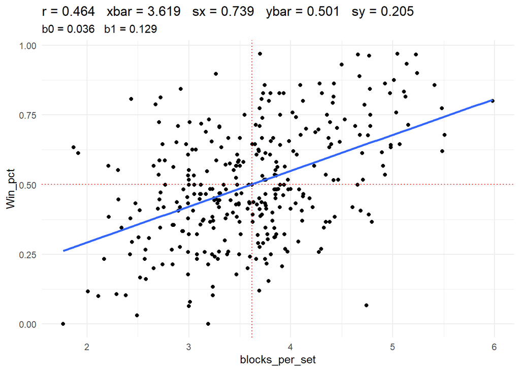

```r
f(vb, digs_per_set, Win_pct)
```

```
## # A tibble: 1 x 7
##      mx    sx    my    sy     r     b1     b0
##   <dbl> <dbl> <dbl> <dbl> <dbl>  <dbl>  <dbl>
## 1  14.8  1.51 0.501 0.205 0.238 0.0324 0.0219
```

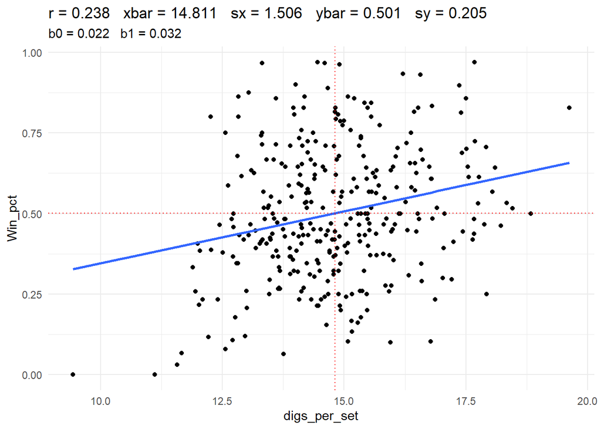

```r
f(vb, kills_per_set, Win_pct)
```

```
## # A tibble: 1 x 7
##      mx    sx    my    sy     r    b1    b0
##   <dbl> <dbl> <dbl> <dbl> <dbl> <dbl> <dbl>
## 1  12.5  1.15 0.501 0.205 0.822 0.146 -1.32
```

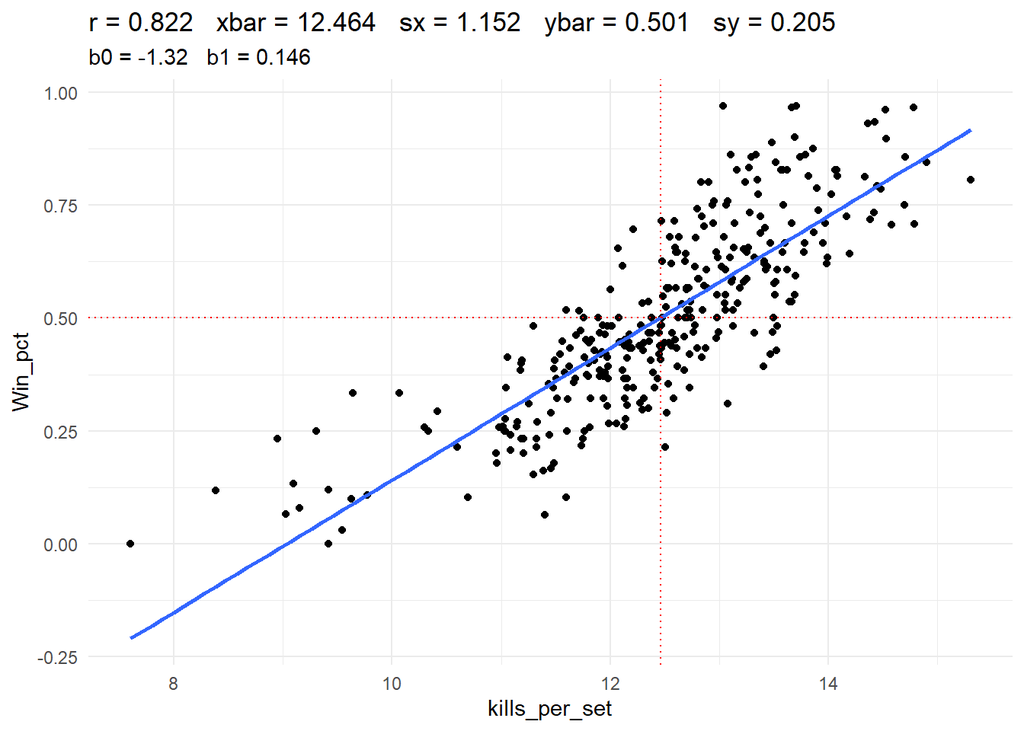

```r
f(vb, errors_per_set, Win_pct)
```

```
## # A tibble: 1 x 7
##      mx    sx    my    sy      r     b1    b0
##   <dbl> <dbl> <dbl> <dbl>  <dbl>  <dbl> <dbl>
## 1  5.27 0.541 0.501 0.205 -0.490 -0.185  1.48
```

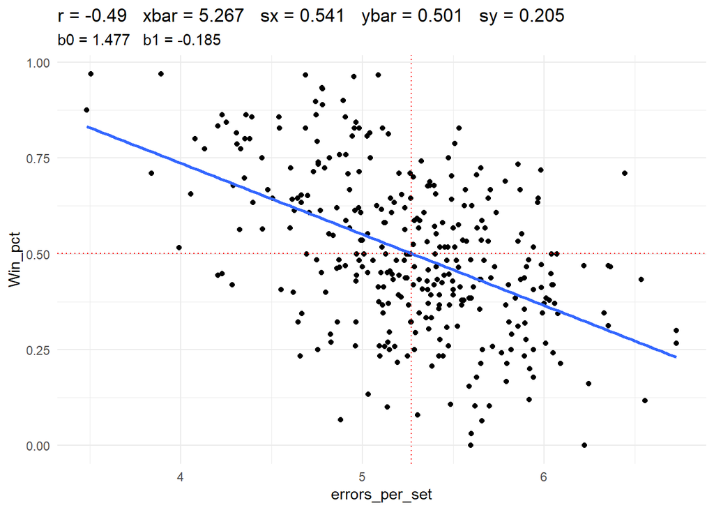

```r
## Example with a very strong negative correlation
f(vb, W, L)
```

```
## # A tibble: 1 x 7
##      mx    sx    my    sy      r     b1    b0
##   <dbl> <dbl> <dbl> <dbl>  <dbl>  <dbl> <dbl>
## 1  14.8  6.18  14.6  5.99 -0.931 -0.902  27.9
```

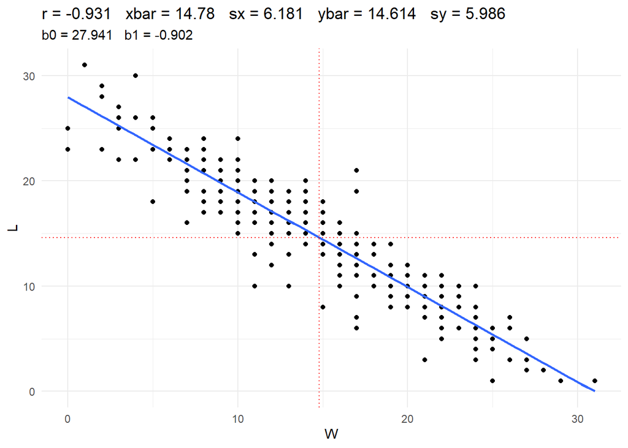

### Get Big 10 Data

```r
big10 = vb %>%
  filter(Conference == "Big Ten")
```

### Kills per Set

```r
p = f(big10, kills_per_set, Win_pct)
```

```
## # A tibble: 1 x 7
##      mx    sx    my    sy     r    b1    b0
##   <dbl> <dbl> <dbl> <dbl> <dbl> <dbl> <dbl>
## 1  13.0  1.11 0.580 0.207 0.795 0.149 -1.35
```

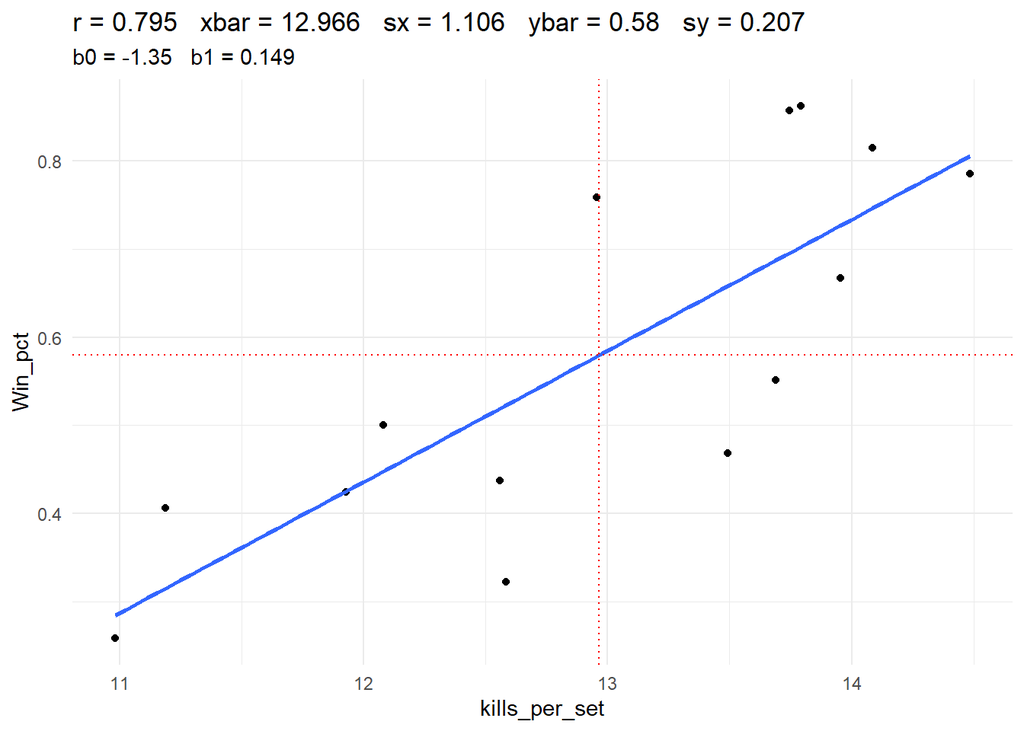

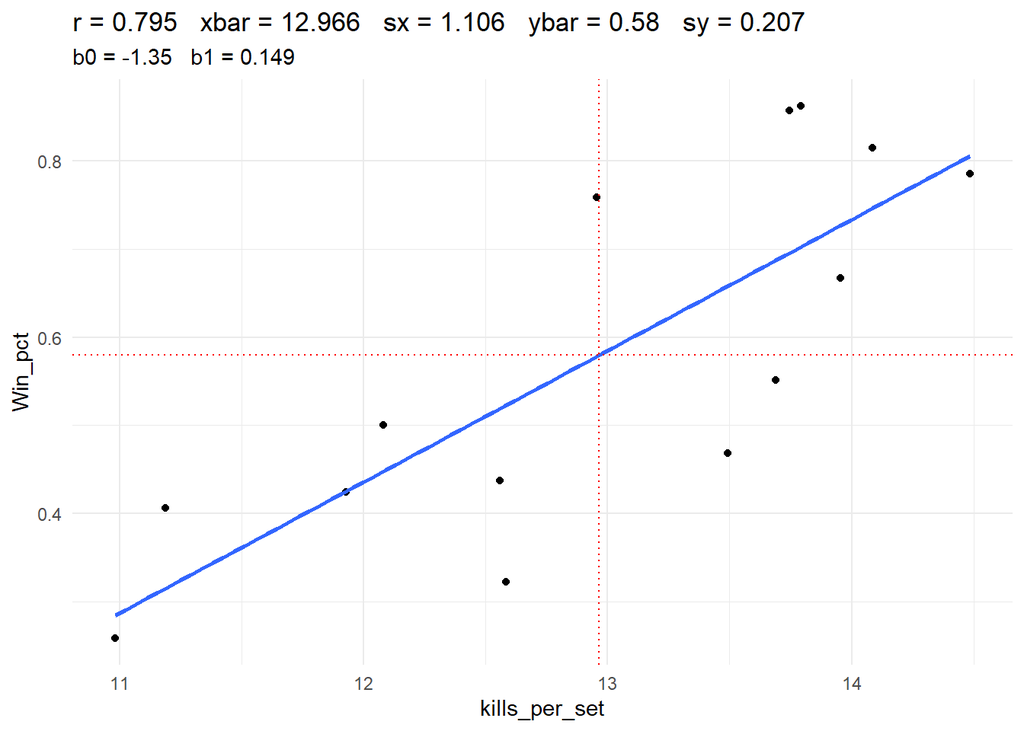

```r
plot(p$plot)
```

### Fitted Values and Residuals

- The function `lm()` is used to fit a linear model.
  - The first argument is a formula
  - `response ~ explanatory variables`
  - The second argument is a data frame
- To fit a simple regression line:
  - The response variable is numerical
  - There is a single numerical explanatory variable
- Fit the regression line to predict `Win_pct` from `kills_per_set` fr the Big 10 data.

```r
fit = lm(Win_pct ~ kills_per_set, data = big10)
```

### See a summary of the fitted model.

```r
summary(fit)
```

```
##
## Call:
## lm(formula = Win_pct ~ kills_per_set, data = big10)
##
## Residuals:
##      Min       1Q   Median       3Q      Max
## -0.19998 -0.07625 -0.01045  0.08552  0.18064
##
## Coefficients:
##               Estimate Std. Error t value Pr(>|t|)
## (Intercept)   -1.35016    0.42693  -3.163 0.008182 **
## kills_per_set  0.14883    0.03282   4.535 0.000683 ***
## ---
## Signif. codes:  0 '***' 0.001 '**' 0.01 '*' 0.05 '.' 0.1 ' ' 1
##
## Residual standard error: 0.1308 on 12 degrees of freedom
## Multiple R-squared:  0.6316, Adjusted R-squared:  0.6009
## F-statistic: 20.57 on 1 and 12 DF,  p-value: 0.0006834
```

- The values under `Estimate` are the intercept ($b_0$) and slope ($b_1$).
- Each estimate has a standard error.
- The `t value` is for a hypothesis test that the parameter equals zero.
  - The test statistic is just the estimate divided by the SE
  - This counts the number of SEs that the estimate is away from zero.
- The value under `P(>|t|)` is the two-sided p-value
  - This is the area in the tails outside of the test statistic and its negative.
- You may ignore other output

### Coefficients

- The function `coef()` returns the estimated coefficients.

```r
coef(fit)
```

```
##   (Intercept) kills_per_set
##    -1.3501612     0.1488341
```

- The coefficients are functions of the means, standard deviations, and correlation coefficient.
  $$b_1 = r \times \frac{s_y}{s_x}$$
  $$b_0 = \bar{y} - b_1\bar{x}$$

```r
p$stats
```

```
## # A tibble: 1 x 7
##      mx    sx    my    sy     r    b1    b0
##   <dbl> <dbl> <dbl> <dbl> <dbl> <dbl> <dbl>
## 1  13.0  1.11 0.580 0.207 0.795 0.149 -1.35
```

```r
## Check the slope
with(p$stats, r * sy/sx)
```

```
## [1] 0.1488341
```

```r
coef(fit)[2]
```

```
## kills_per_set
##     0.1488341
```

```r
## Check the intercept
with(p$stats, my - b1*mx)
```

```
## [1] -1.350161
```

```r
coef(fit)[1]
```

```
## (Intercept)
##   -1.350161
```

### Regression Line

- The regression line is
  $$(\widehat{\text{Win_pct}}) = -1.35 + 0.149(\text{kills per set})$$
- The *fitted values* are the predicted $y$ values.
  - The are the values if you move the points vertically to the line.
- The residuals are the difference between the actual values and the fitted values.
  - positive for points above the line
  - negative for points below the line
- We can use the function `augment()` from the **broom** package to add residuals and fitted values to a data frame.
  - The data frame is formed with `augment(fit)`
  - The variable `.fitted` has the fitted values
  - The variable `.resid` has the residuals
- Only the `x` and `y` variables are retained.
  - Here, I add back in the `Team` variable

```r
big10_aug = augment(fit) %>%
  bind_cols(big10 %>% select(Team)) %>%
  select(Team, kills_per_set, Win_pct, .fitted, .resid)
```

- Iowa is the team with most extreme residual.
- Add the fitted value and residual to the plot.

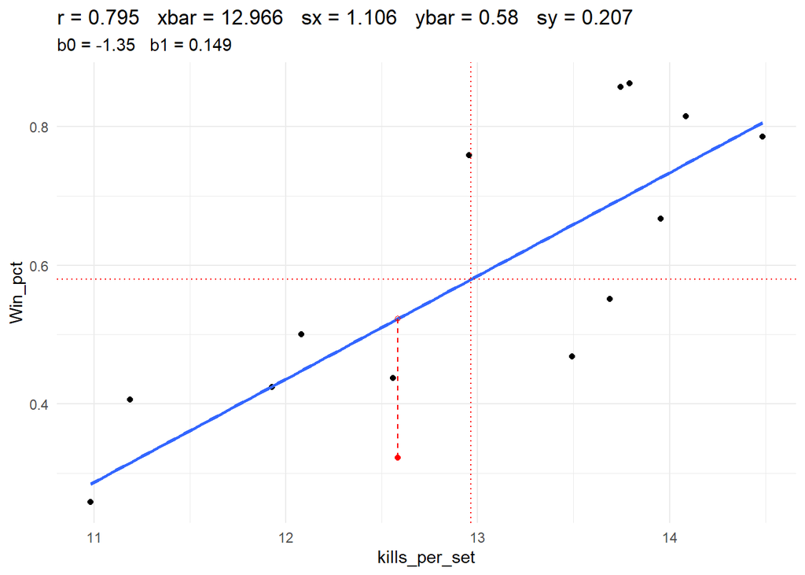

```r
iowa = big10_aug %>%
  filter(Team == "Iowa")

p$plot +
  geom_point(aes(x=kills_per_set, y=Win_pct),
             data = iowa,
             color = "red") +
  geom_point(aes(x=kills_per_set, y=.fitted),
             data = iowa,
             color = "red", pch=1) +
  geom_segment(aes(x = kills_per_set, y=Win_pct,
                   xend = kills_per_set, yend = .fitted),
               data = iowa,
               color = "red", linetype = "dashed")
```

```r
iowa
```

```
## # A tibble: 1 x 5
##   Team  kills_per_set Win_pct .fitted .resid
##   <chr>         <dbl>   <dbl>   <dbl>  <dbl>
## 1 Iowa           12.6   0.323   0.523 -0.200
```